# UKBB Simulation Report

This document reports the results of single effect regression simulations generated from UKBB genotypes. We use one locus with $n = 50,000$ individuals and $p = 3312$ SNPs. In each simulation we randomly select as SNP and then simulate an effect size to achieve achieve a desired heritability of risk varying from 0.5% to 16%. Finally, we simulate observed case/control status for the 50k individuals.

Importantly, since we work with normalized genotypes, we have ensured that the a fixed prior variance of $\sigma^2_0=1$ is appropriate, and in the logistic models we can compare the performance of a fixed prior variance to the empirical Bayes procedure where we estimate $\sigma^2_0$.

```r
#project_dir <- snakemake@config$project_dir
project_dir <-  '/project2/mstephens/ktayeb/logistic-susie-snakemake'
knitr::opts_knit$set(root.dir = project_dir)
```

```r
library(dplyr)
```

```r
library(dplyr)
library(reticulate)
library(tidyr)
library(tictoc)
library(ggplot2)

source('workflow/scripts/plotting/plot_functions.R')
source('workflow/scripts/ukbb_geno/pip_and_cs_summary.R')
```

```r
# httpgd::hgd()
res_pip <- readRDS("results/ukbb_geno/chr1_100794065_101983457/ser_pip_summary.rds")
res_cs <- readRDS("results/ukbb_geno/chr1_100794065_101983457/ser_cs_summary.rds")
manifest <- readr::read_delim('config/ukbb_sim/ukbb_ser_manifest.tsv', delim='\t')
# list methods to use here
methods = tribble(
    ~ method,
    'linear_susie_L1eb',
    'gibss_labf_L1eb',
    'gibss_labf_L1',
    'gibss_abf_L1eb',
    'gibss_abf_L1',
    'quad_ser_L1eb',
    'quad_ser_L1'
)

# load fits
# long format so each row corresponds to a (simulation, method), and there is a column for each model
tic('load fits')
fits <- manifest %>%
    select(region, sim_id) %>%
    crossing(methods) %>%
    rowwise() %>%
    mutate(path = glue::glue('results/ukbb_geno/{region}/{sim_id}/{method}.rds')) %>%
    mutate(fit = list(load_gibssr(path))) %>%
    select(c(sim_id, method, fit))
toc()
```

```
## load fits: 37.231 sec elapsed
```

```r
tic('load simulations')
sims <- manifest %>%
    rowwise() %>%
    mutate(sim = readRDS(glue::glue('results/ukbb_geno/{region}/{sim_id}/sim.rds')))
toc()
```

```
## load simulations: 8.489 sec elapsed
```

```r
method_order <- c('quad_ser_L1', 'quad_ser_L1eb', 'gibss_labf_L1', 'gibss_labf_L1eb', 'gibss_abf_L1', 'gibss_abf_L1eb', 'linear_susie_L1eb')

fits <- fits %>%
    mutate(method = factor(method,  method_order))

res_cs <- res_cs %>%
    mutate(method = factor(method,  method_order))

res_pip <- res_pip %>%
    mutate(method = factor(method,  method_order))
```

```r
#' filter df by comp(var, val)
threshold_var <- function(df, var, val, comp){
  filter(df, comp(.data[[var]], !!val))
}

cs_filtered_coverage <- function(res_cs, var, val, comp){
    # count number of true causal effects across all simulations
    Q_tbl <- res_cs %>%
        select(c(method, sim_id, q)) %>%
        unique() %>%
        group_by(method) %>%
        summarize(Q = sum(q))

    res_cs %>%
        threshold_var(var, val, comp) %>%
        mutate(val = val) %>% # record threshold values
        group_by(method) %>%
        summarize(
            unique_found = length(unique(idx)),
            coverage = mean(covered),
            n_found2 = list(table(n_found)),
            mean_cs_size = mean(cs_size),
            val = val[1],
            n_found = sum(n_found)) %>%
        left_join(Q_tbl) %>%
        unnest_wider(n_found2)
}

make_plot <- function(res_cs, var, vals, op){
    f <- function(val){
        res_cs %>%
            cs_filtered_coverage(var, val, op)
    }
    filtered_coverage <- purrr::map_dfr(vals, f)

    a <- filtered_coverage %>%
        ggplot(aes(x = val, y = coverage, color = method)) +
        geom_path() +
        geom_hline(yintercept = 0.95) +
        xlab(var)

    b <- filtered_coverage %>%
        mutate(power = n_found/Q) %>%
        mutate(power = `1`/Q) %>%
        ggplot(aes(x = val, y = power, color = method)) +
        geom_path() +
        xlab(var)

    cowplot::plot_grid(a, b)
}
```

## SER simulations

### Simulation settings

```r
# show unique simulation settings for SER simulations
manifest %>%
    filter(name == 'ser') %>%
    select(c(q, k, h2, rho, gamma)) %>%
    unique() %>%
    rmarkdown::paged_table()
```

| q | k | h2 | rho | gamma |
| --- | --- | --- | --- | --- |
| 1 | 0.005 | 0.01 | 0.5 | 0.005 |
| 1 | 0.005 | 0.02 | 0.5 | 0.010 |
| 1 | 0.005 | 0.04 | 0.5 | 0.020 |
| 1 | 0.005 | 0.08 | 0.5 | 0.040 |
| 1 | 0.005 | 0.16 | 0.5 | 0.080 |
| 1 | 0.005 | 0.32 | 0.5 | 0.160 |
| 1 | 0.010 | 0.01 | 0.5 | 0.005 |
| 1 | 0.010 | 0.02 | 0.5 | 0.010 |
| 1 | 0.010 | 0.04 | 0.5 | 0.020 |
| 1 | 0.010 | 0.08 | 0.5 | 0.040 |

[output cut: 20 more lines]

### Credible sets

#### CS size distribution

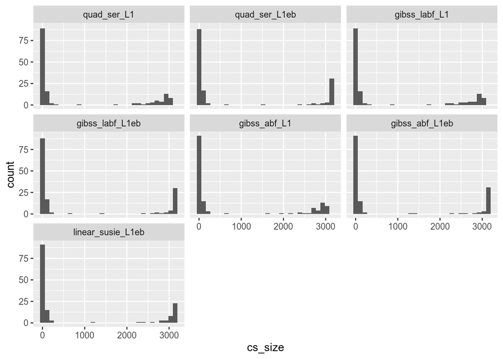

```r
# histogram of CSs, and coverage over all simulations
res_cs %>%
    filter(name == 'ser') %>%
    ggplot(aes(x = cs_size)) +
    geom_histogram() +
    facet_wrap(vars(method))
```

#### CS coverage

We assess the coverage of the credible sets. Estimating the prior variance hurts the coverage of the credible sets for the logistic SER with BFs computed by the Laplace approximation and quadrature, but not for Wakefield. All the methods have good coverage if we filter out obviously uninformative CSs, e.g. here by removing CSs with size > 200 all the methods have good coverage.

```r
res_cs %>%
    filter(name == 'ser') %>%
    #filter(cs_size < 200) %>%
    group_by(method) %>%
    summarize(coverage = mean(covered), n_found = list(table(n_found)), mean_cs_size = mean(cs_size)) %>%
    unnest_wider(n_found) %>%
    knitr::kable()
```

| method | coverage | 0 | 1 | mean_cs_size |
| --- | --- | --- | --- | --- |
| quad_ser_L1 | 0.9733333 | 4 | 146 | 777.4200 |
| quad_ser_L1eb | 0.9200000 | 12 | 138 | 869.1467 |
| gibss_labf_L1 | 0.9733333 | 4 | 146 | 776.0867 |
| gibss_labf_L1eb | 0.9200000 | 12 | 138 | 865.1000 |
| gibss_abf_L1 | 0.9600000 | 6 | 144 | 764.3600 |
| gibss_abf_L1eb | 0.9666667 | 5 | 145 | 853.9267 |
| linear_susie_L1eb | 0.9466667 | 8 | 142 | 833.5333 |

```r
res_cs %>%
    filter(name == 'ser') %>%
    filter(cs_size < 200) %>%
    group_by(method) %>%
    summarize(coverage = mean(covered), n_found = list(table(n_found)), mean_cs_size = mean(cs_size)) %>%
    unnest_wider(n_found) %>%
    knitr::kable()
```

| method | coverage | 0 | 1 | mean_cs_size |
| --- | --- | --- | --- | --- |
| quad_ser_L1 | 0.9813084 | 2 | 105 | 23.73832 |
| quad_ser_L1eb | 0.9811321 | 2 | 104 | 22.89623 |
| gibss_labf_L1 | 0.9813084 | 2 | 105 | 23.71028 |
| gibss_labf_L1eb | 0.9811321 | 2 | 104 | 22.85849 |
| gibss_abf_L1 | 0.9626168 | 4 | 103 | 21.59813 |
| gibss_abf_L1eb | 0.9626168 | 4 | 103 | 22.46729 |
| linear_susie_L1eb | 0.9532710 | 5 | 102 | 21.83178 |

#### Conditional coverage

Here we check the coverage of the CSs based on simple filters to remove the uninformative CSs. We filter on purity, CS size, and the log BF.

Laplace approximation and quadrature are indistinguishable on these plots, indicating good quality of the Laplace approximation.

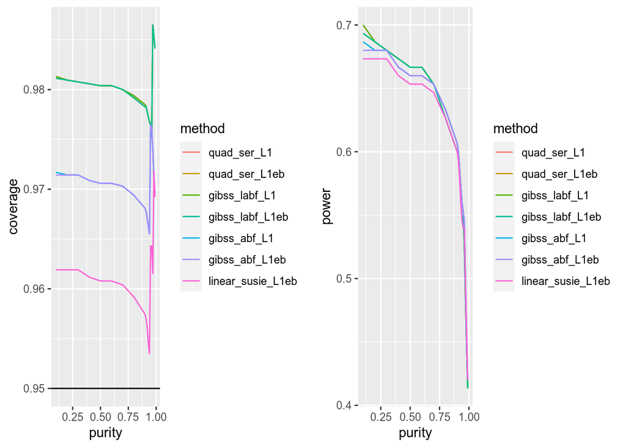

```r
# filter on purity
vals <- c(seq(0.1, 0.9, by = 0.1), seq(0.91, .99, by = 0.01))
res_cs %>% filter(name == 'ser') %>% make_plot('purity', vals, `>`)
```

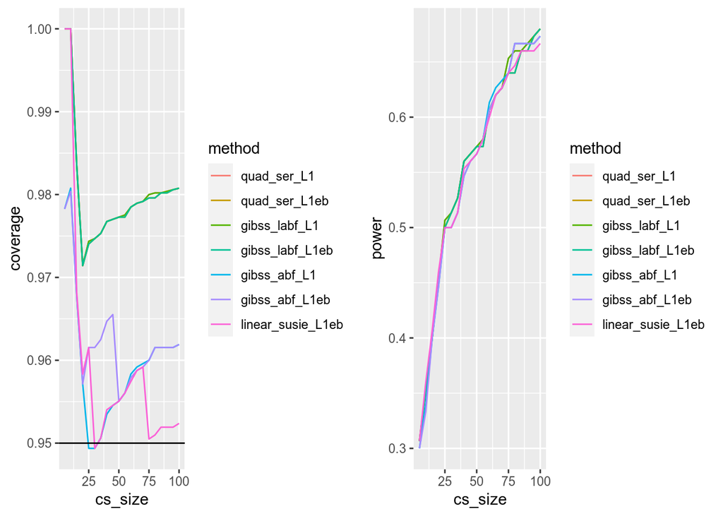

```r
# filter on cs size
vals <- seq(5, 100, by=5)
res_cs %>% filter(name == 'ser') %>% make_plot('cs_size', vals, `<`)
```

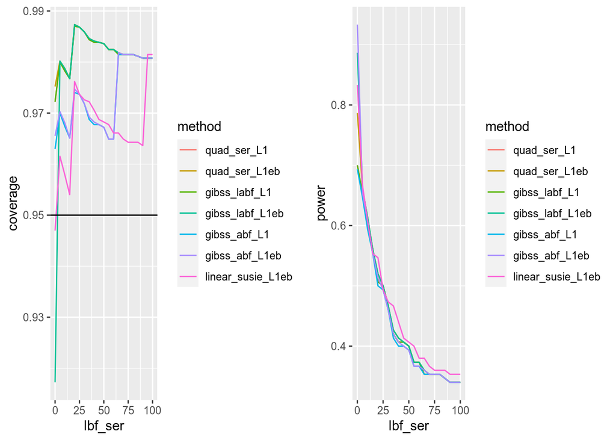

```r
# filter on the SER-level BFs
# note multiple CSs may capture the same effect causing "power" > 1
vals <- seq(0, 100, by=5)
res_cs %>% filter(name == 'ser') %>% make_plot('lbf_ser', vals, `>`)
```

### Credible set sizes

We compare the CS sizes for each approximation against the “exact” CS size from `L1_quad_ser`, which is the logistic SER with the correct prior variance, and BFs computed via quadrature.

The Wakefield BF and linear SERs show the poorest agreement with the “exact” logistic SER. Often, the reported CSs are smaller. The CSs that do not contain a causal variable are denoted by an open circle. The top left panel shows the mistakes that the reference model makes, we see that the ABF and linear SER methods make a few more errors compared to the quadrature and Laplace BF methods.

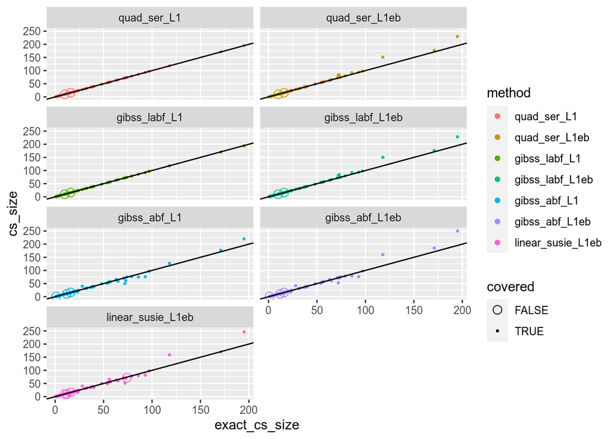

```r
exact_cs_size <- res_cs %>%
    filter(method == 'quad_ser_L1') %>%
    select(c(sim_id, cs_size)) %>%
    rename(exact_cs_size=cs_size)

res_cs %>%
    select(sim_id, method, cs_size, covered) %>%
    left_join(exact_cs_size) %>%
    filter(exact_cs_size < 200) %>%
    #mutate(method = factor(method, method_order)) %>%
    ggplot(aes(x=exact_cs_size, y=cs_size, color=method, shape=covered, size=covered)) + geom_point() +
    facet_wrap(vars(method), ncol=2) + geom_abline() +
    scale_shape_manual(values=c(1, 20)) +
    scale_size_manual(values=c(3, 1))
```

### Power vs FDP (PIP ordering)

Quadrature and Laplace are again indistinguishable, and have the best power in these simulations.

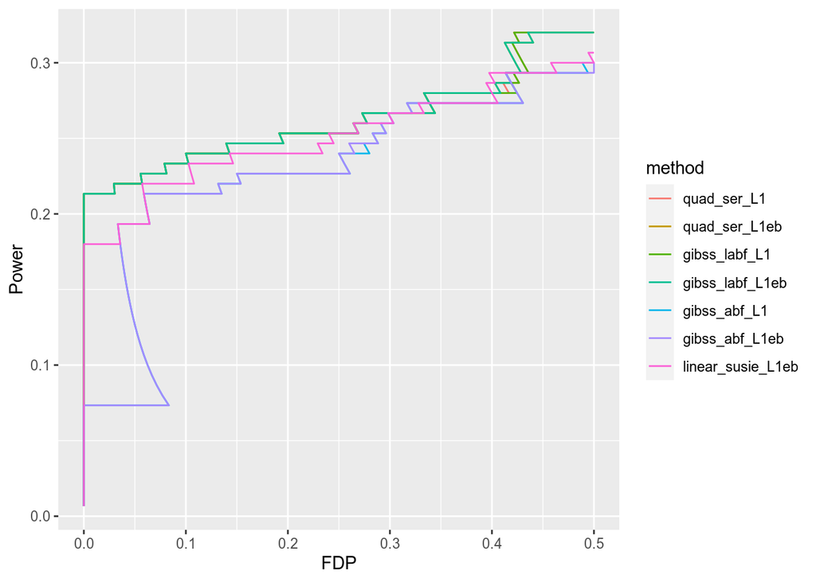

```r
# fdp vs power
fdp_plot <- res_pip %>%
    filter(name == 'ser') %>%
    unnest_longer(c(pip, causal)) %>%
    mutate(method = factor(method, method_order)) %>%
    ggplot(aes(pip, causal, color=method)) +
    stat_fdp_power(geom='path', max_fdp=0.5) +
    labs(x = 'FDP', y = 'Power')
fdp_plot
```

### PIP Calibration

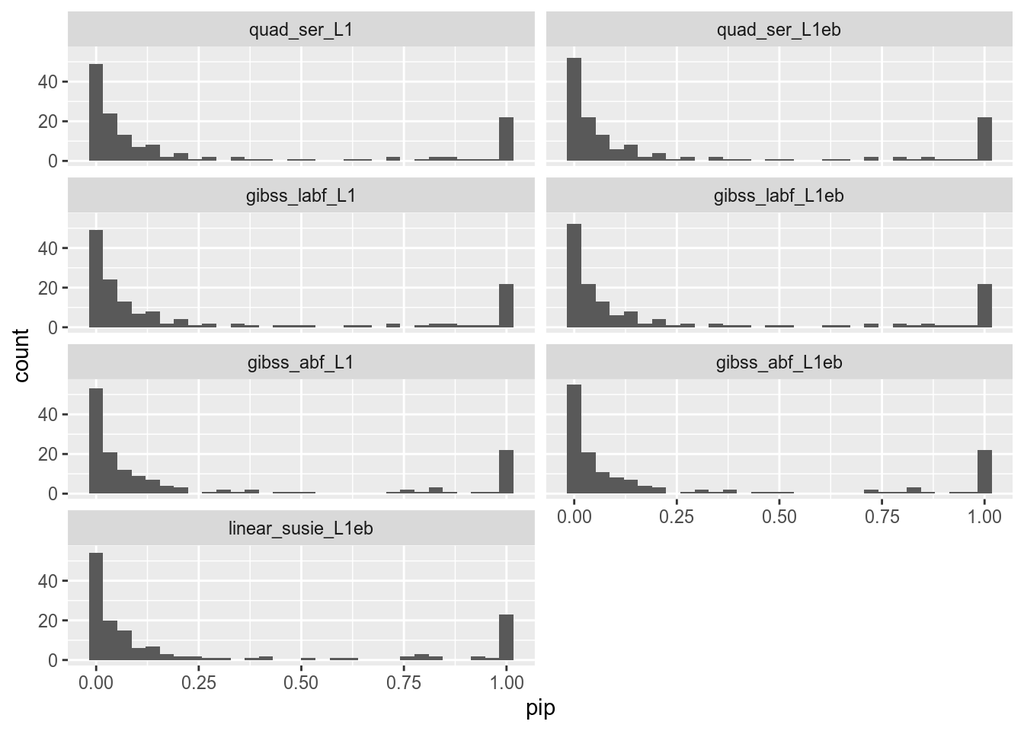

```r
res_pip  %>%
    filter(name == 'ser') %>%
    unnest_longer(c(pip, causal)) %>%
    filter(causal == 1) %>%
    ggplot(aes(pip)) + geom_histogram() + facet_wrap(vars(method), ncol=2)
```

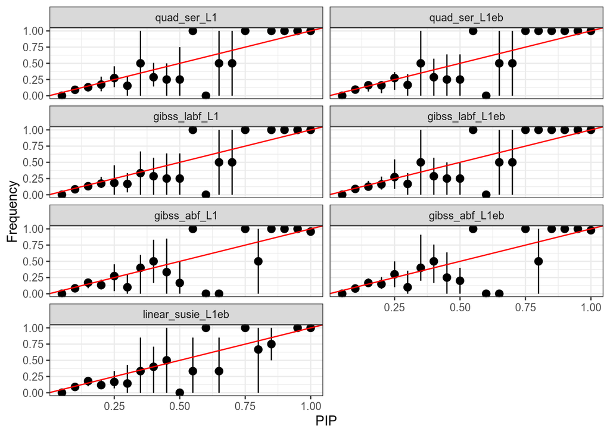

```r
pip_calibration_plot <- res_pip %>%
    filter(name == 'ser') %>%
    unnest_longer(c(pip, causal)) %>%
    ggplot(aes(pip, causal)) +
    stat_pip_calibration() +
    geom_abline(intercept = 0, slope = 1, color='red') +
    theme_bw() +
    labs(x='PIP', y='Frequency') +
    facet_wrap(vars(method), ncol=2)
pip_calibration_plot
```

### BF comparisons

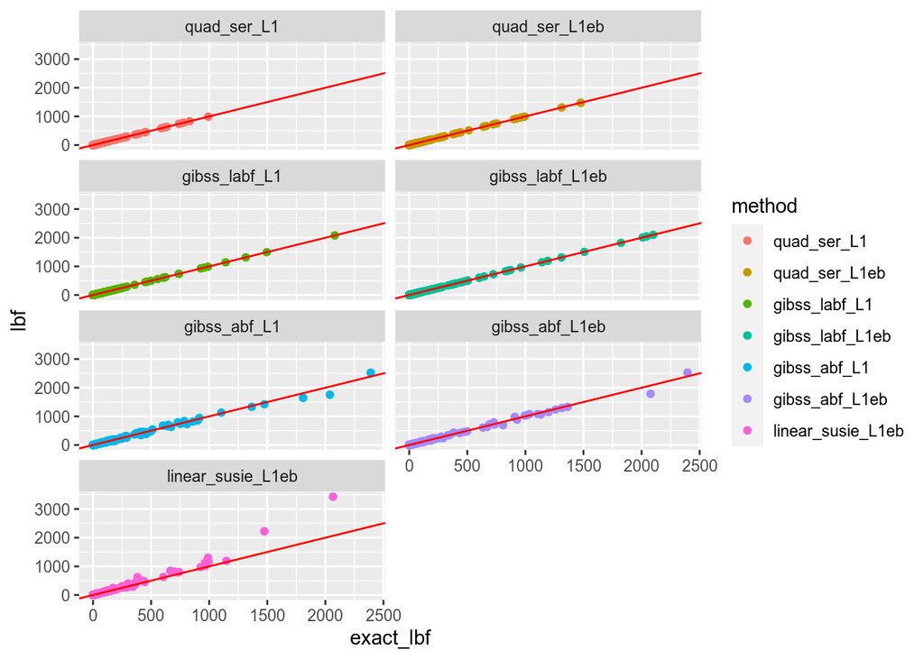

```r
lbfs <- fits %>%
    tidyr::hoist(fit, 'lbf', 'lbf_variable', .simplify=F) %>%
    rowwise() %>%
    # a fix: for linear ser lbfs are stored in lbf_variable
    mutate(lbf = ifelse(grepl('linear', method), list(lbf_variable[1,]), list(lbf[1,]))) %>%
    mutate(idx = list(1:length(lbf))) %>%
    select(c(sim_id, method, idx, lbf)) %>%
    tidyr::unnest(c(idx, lbf))

exact_lbfs <- lbfs %>%
    filter(method == 'quad_ser_L1') %>%
    rename(exact_lbf = lbf) %>%
    select(c(sim_id, idx, exact_lbf))

causal_variables <- sims %>%
    hoist(sim, 'idx') %>%
    rename(causal = idx) %>%
    select(sim_id, causal)

# plot fraction of log BFs
lbfs %>%
    left_join(exact_lbfs) %>%
    filter(exact_lbf > 0) %>%
    dplyr::sample_frac(0.01) %>%
    ggplot(aes(x=exact_lbf, y = lbf, color=method)) +
        facet_wrap(vars(method), ncol=2) +
        geom_point() +
        geom_abline(slope=1, intercept=0, color='red')
```

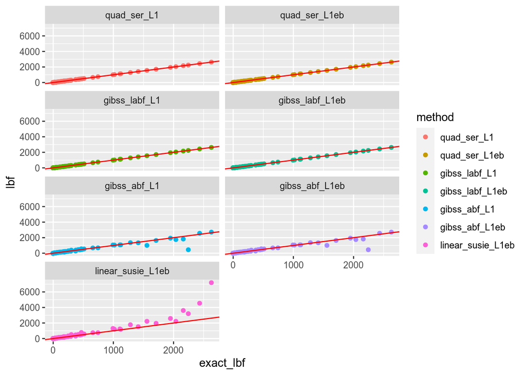

```r
# plot log BFs of causal variables
lbfs %>%
    left_join(causal_variables) %>%
    filter(idx == causal) %>%
    left_join(exact_lbfs) %>%
    ggplot(aes(x=exact_lbf, y = lbf, color=method)) +
        facet_wrap(vars(method), ncol=2) +
        geom_point() +
        geom_abline(slope=1, intercept=0, color='red')
```

### Where ABF and LABF disagree significantly

The largest error resulted in a false positive for ABF, in other cases it seems that even though there was a large discrpency in the BFs, ABF still selects the right variable because the approximate BF is still overwhelmingly large.

```r
# here are simulations where ABF is way off for the causal variable
abf_poor_examples <- lbfs %>%
    left_join(causal_variables) %>%
    filter(idx == causal) %>%
    left_join(exact_lbfs) %>%
    pivot_wider(names_from = method, values_from = lbf) %>%
    filter(abs(exact_lbf - gibss_abf_L1) > 100) %>%
    select(c(sim_id, quad_ser_L1, gibss_abf_L1)) %>%
    mutate(delta = quad_ser_L1 - gibss_abf_L1) %>%
    arrange(desc(abs(delta)))
# very small CSs-- even though the ABF is wrong it is still big compared to other ABFs...
abf_poor_examples %>%
    left_join(res_cs %>% select(sim_id, method, cs_size, covered)) %>%
    #filter(sim_id %in% abf_poor_examples$sim_id) %>%
    filter(method %in% c('gibss_abf_L1', 'quad_ser_L1'))
```

```
## # A tibble: 10 × 7
##    sim_id quad_ser_L1 gibss_abf_L1 delta method       cs_size covered
##    <chr>        <dbl>        <dbl> <dbl> <fct>          <dbl> <lgl>
##  1 37e52        2245.         447. 1798. gibss_abf_L1       1 FALSE
##  2 37e52        2245.         447. 1798. quad_ser_L1        1 TRUE
##  3 17126        1558.        1004.  554. gibss_abf_L1       1 TRUE
##  4 17126        1558.        1004.  554. quad_ser_L1        1 TRUE
##  5 34593        2162.        1823.  338. gibss_abf_L1       3 TRUE
##  6 34593        2162.        1823.  338. quad_ser_L1        2 TRUE
##  7 a3d0b        2038.        1754.  285. gibss_abf_L1       3 TRUE
##  8 a3d0b        2038.        1754.  285. quad_ser_L1        3 TRUE
##  9 1ce67        2433.        2564. -131. gibss_abf_L1       1 TRUE
## 10 1ce67        2433.        2564. -131. quad_ser_L1        1 TRUE
```

```r
# here are simulations where ABF is way off for the causal variable
abf_poor_examples <- lbfs %>%
    left_join(causal_variables) %>%
    filter(idx == causal) %>%
    left_join(exact_lbfs) %>%
    pivot_wider(names_from = method, values_from = lbf) %>%
    filter(abs(exact_lbf - gibss_abf_L1) > 2, abs(exact_lbf - gibss_abf_L1) < 10) %>%
    select(c(sim_id, quad_ser_L1, gibss_abf_L1)) %>%
    mutate(delta = quad_ser_L1 - gibss_abf_L1) %>%
    arrange(desc(abs(delta)))
# very small CSs-- even though the ABF is wrong it is still big compared to other ABFs...
abf_poor_examples %>%
    left_join(res_cs %>% select(sim_id, method, cs_size, covered)) %>%
    #filter(sim_id %in% abf_poor_examples$sim_id) %>%
    filter(method %in% c('gibss_abf_L1', 'quad_ser_L1'))
```

```
## # A tibble: 52 × 7
##    sim_id quad_ser_L1 gibss_abf_L1 delta method       cs_size covered
##    <chr>        <dbl>        <dbl> <dbl> <fct>          <dbl> <lgl>
##  1 bf96d         58.4         68.0 -9.66 gibss_abf_L1      17 TRUE
##  2 bf96d         58.4         68.0 -9.66 quad_ser_L1       18 TRUE
##  3 620d2         18.0         27.6 -9.63 gibss_abf_L1      12 TRUE
##  4 620d2         18.0         27.6 -9.63 quad_ser_L1       15 TRUE
##  5 43802        122.         130.  -8.38 gibss_abf_L1       2 TRUE
##  6 43802        122.         130.  -8.38 quad_ser_L1        2 TRUE
##  7 e6334         37.8         45.7 -7.90 gibss_abf_L1      18 TRUE
##  8 e6334         37.8         45.7 -7.90 quad_ser_L1       23 TRUE
##  9 cf23e        105.         113.  -7.66 gibss_abf_L1      35 TRUE
## 10 cf23e        105.         113.  -7.66 quad_ser_L1       37 TRUE
## # ℹ 42 more rows
```